# Du_Isabelle_HW2

Name: Isabelle Du  
Github Username: yxd-1213  
USC ID: 5984907579

## 1. Combined Cycle Power Plant Data Set

### (a) Download Data

Package imports

```python
import pandas as pd
import numpy as np
import matplotlib.pyplot as plt
import seaborn as sns

import statsmodels.api as sm
import statsmodels.formula.api as smf

from sklearn.model_selection import train_test_split
from sklearn.preprocessing import StandardScaler, PolynomialFeatures
from sklearn.neighbors import KNeighborsRegressor
from sklearn.metrics import mean_squared_error
```

Get the Cycle Power Plant Data Set

```python
data = pd.read_excel(
    "CCPP/Folds5x2_pp.xlsx",
    sheet_name="Sheet1"
)

data.head()
```

|  | AT | V | AP | RH | PE |
| --- | --- | --- | --- | --- | --- |
| 0 | 14.96 | 41.76 | 1024.07 | 73.17 | 463.26 |
| 1 | 25.18 | 62.96 | 1020.04 | 59.08 | 444.37 |
| 2 | 5.11 | 39.40 | 1012.16 | 92.14 | 488.56 |
| 3 | 20.86 | 57.32 | 1010.24 | 76.64 | 446.48 |
| 4 | 10.82 | 37.50 | 1009.23 | 96.62 | 473.90 |

#### i. rows and columns

```python
# Number of rows and columns
data.shape
```

```
(9568, 5)
```

```python
# Column names
data.columns
```

```
Index(['AT', 'V', 'AP', 'RH', 'PE'], dtype='str')
```

There are 9,568 rows and 5 columns in the dataset.

Each row represents one hourly observation collected from the Combined Cycle Power Plant.

The columns represent:

- AT: Ambient Temperature
- V: Exhaust Vacuum
- AP: Ambient Pressure
- RH: Relative Humidity
- PE: Net hourly electrical energy output

#### ii. pairwise scatterplots of all the varianbles

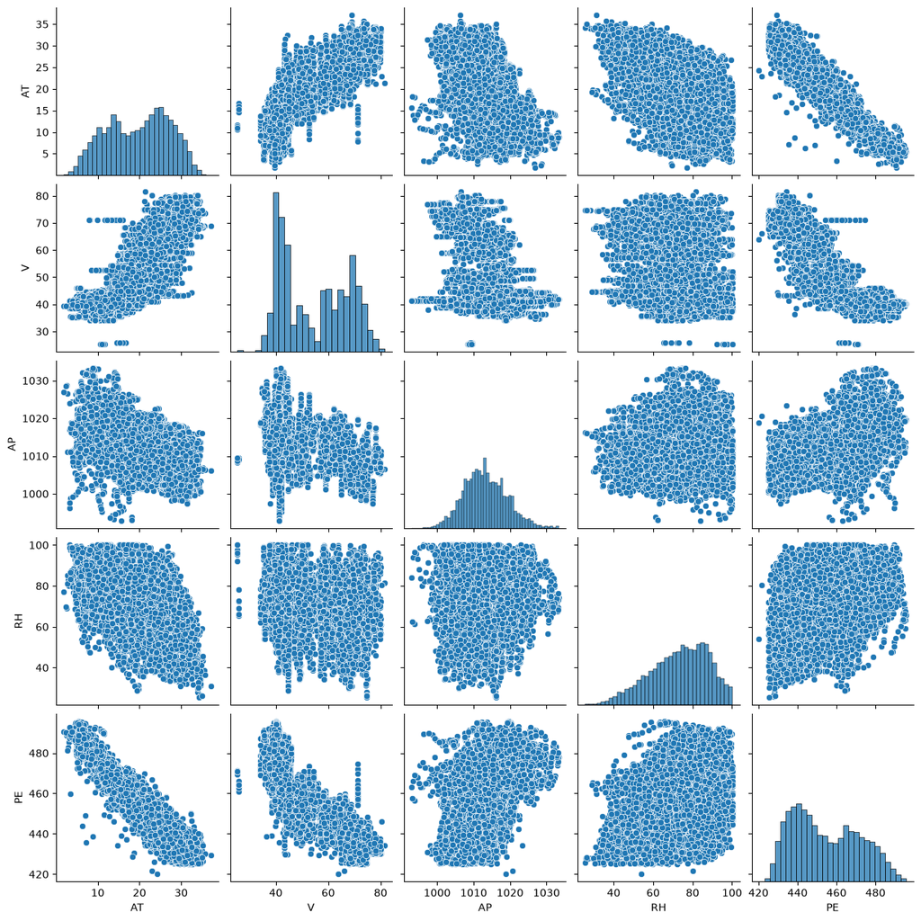

```python
# Pairwise scatterplots of all variables
sns.pairplot(data)
plt.show()
```

**Findings:**

The pairwise scatterplots show that PE has a strong negative relationship with AT and V. As ambient temperature and exhaust vacuum increase, the electrical power output generally decreases.

AP appears to have a weaker positive relationship with PE, while RH also shows a relatively weak positive relationship with PE.

There are also noticeable relationships among some of the predictors. For example, AT and V are positively associated, while AT appears to be negatively associated with AP and RH. Overall, AT and V seem to have the strongest relationships with PE.

#### iii. mean, the median, range, first and third quartiles, and interquartile ranges

```python
# Summary statistics for each variable

summary_stats = pd.DataFrame({
    'Mean': data.mean(),
    'Median': data.median(),
    'Range': data.max() - data.min(),
    'Q1': data.quantile(0.25),
    'Q3': data.quantile(0.75),
    'IQR': data.quantile(0.75) - data.quantile(0.25)
})

summary_stats
```

|  | Mean | Median | Range | Q1 | Q3 | IQR |
| --- | --- | --- | --- | --- | --- | --- |
| AT | 19.651231 | 20.345 | 35.30 | 13.5100 | 25.72 | 12.2100 |
| V | 54.305804 | 52.080 | 56.20 | 41.7400 | 66.54 | 24.8000 |
| AP | 1013.259078 | 1012.940 | 40.41 | 1009.1000 | 1017.26 | 8.1600 |
| RH | 73.308978 | 74.975 | 74.60 | 63.3275 | 84.83 | 21.5025 |
| PE | 454.365009 | 451.550 | 75.50 | 439.7500 | 468.43 | 28.6800 |

### (c) Simple Linear Regression

```python
# Simple linear regression for each predictor

predictors = ['AT', 'V', 'AP', 'RH']
simple_models = {}

for predictor in predictors:
    model = smf.ols(f'PE ~ {predictor}', data=data).fit()
    simple_models[predictor] = model
```

```python
# Summary of simple linear regression results

simple_results = []

for predictor in predictors:
    model = simple_models[predictor]

    simple_results.append({
        'Predictor': predictor,
        'Coefficient': model.params[predictor],
        'Std. Error': model.bse[predictor],
        't-statistic': model.tvalues[predictor],
        'p-value': model.pvalues[predictor],
        'R-squared': model.rsquared
    })

simple_results = pd.DataFrame(simple_results)
simple_results
```

|  | Predictor | Coefficient | Std. Error | t-statistic | p-value | R-squared |
| --- | --- | --- | --- | --- | --- | --- |
| 0 | AT | -2.171320 | 0.007443 | -291.715195 | 0.0 | 0.898948 |
| 1 | V | -1.168135 | 0.006776 | -172.401540 | 0.0 | 0.756518 |
| 2 | AP | 1.489872 | 0.025126 | 59.296232 | 0.0 | 0.268769 |
| 3 | RH | 0.455650 | 0.011006 | 41.398730 | 0.0 | 0.151939 |

**Results:**

All four predictors have statistically significant associations with PE, since their p-values are all below 0.05.

AT has a strong negative association with PE, with a coefficient of -2.1713 and an R-squared of 0.8989. This indicates that AT alone explains about 89.9% of the variation in PE.

V also has a strong negative association with PE, with a coefficient of -1.1681 and an R-squared of 0.7565.

AP and RH both have positive and statistically significant associations with PE, but their R-squared values are much lower (0.2688 and 0.1519, respectively), indicating weaker explanatory power when used individually.

Overall, AT shows the strongest simple linear relationship with PE, followed by V.

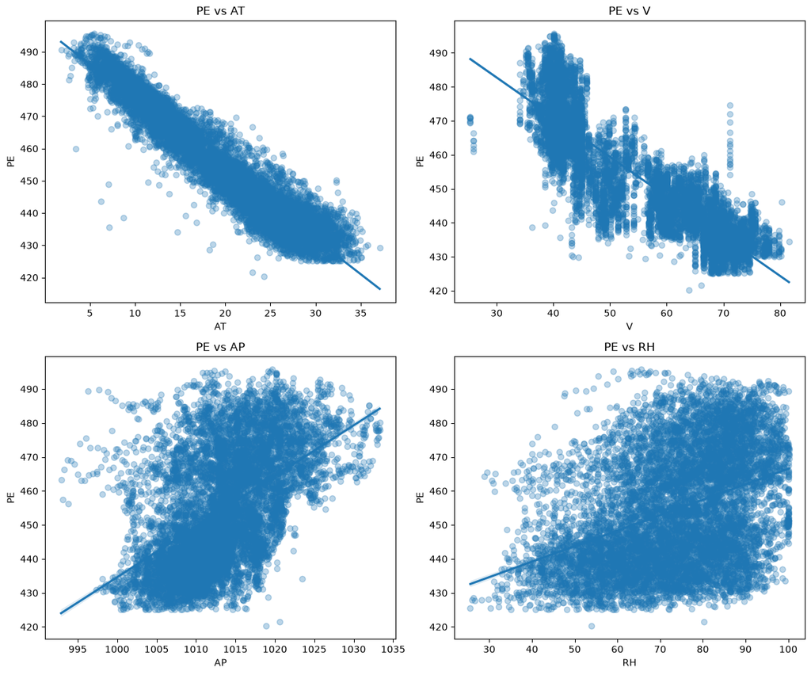

```python
# Scatterplots with simple linear regression lines

fig, axes = plt.subplots(2, 2, figsize=(12, 10))

for predictor, ax in zip(predictors, axes.flatten()):
    sns.regplot(x=predictor, y='PE', data=data,
                scatter_kws={'alpha': 0.3}, ax=ax)
    ax.set_title(f'PE vs {predictor}')

plt.tight_layout()
plt.show()
```

```python
# Check potential outliers using studentized residuals

outlier_results = []

for predictor in predictors:
    model = simple_models[predictor]
    influence = model.get_influence()
    studentized_residuals = influence.resid_studentized_internal

    outliers = np.where(np.abs(studentized_residuals) > 3)[0]

    outlier_results.append({
        'Predictor': predictor,
        'Number of Potential Outliers': len(outliers)
    })

outlier_results = pd.DataFrame(outlier_results)
outlier_results
```

|  | Predictor | Number of Potential Outliers |
| --- | --- | --- |
| 0 | AT | 42 |
| 1 | V | 33 |
| 2 | AP | 29 |
| 3 | RH | 2 |

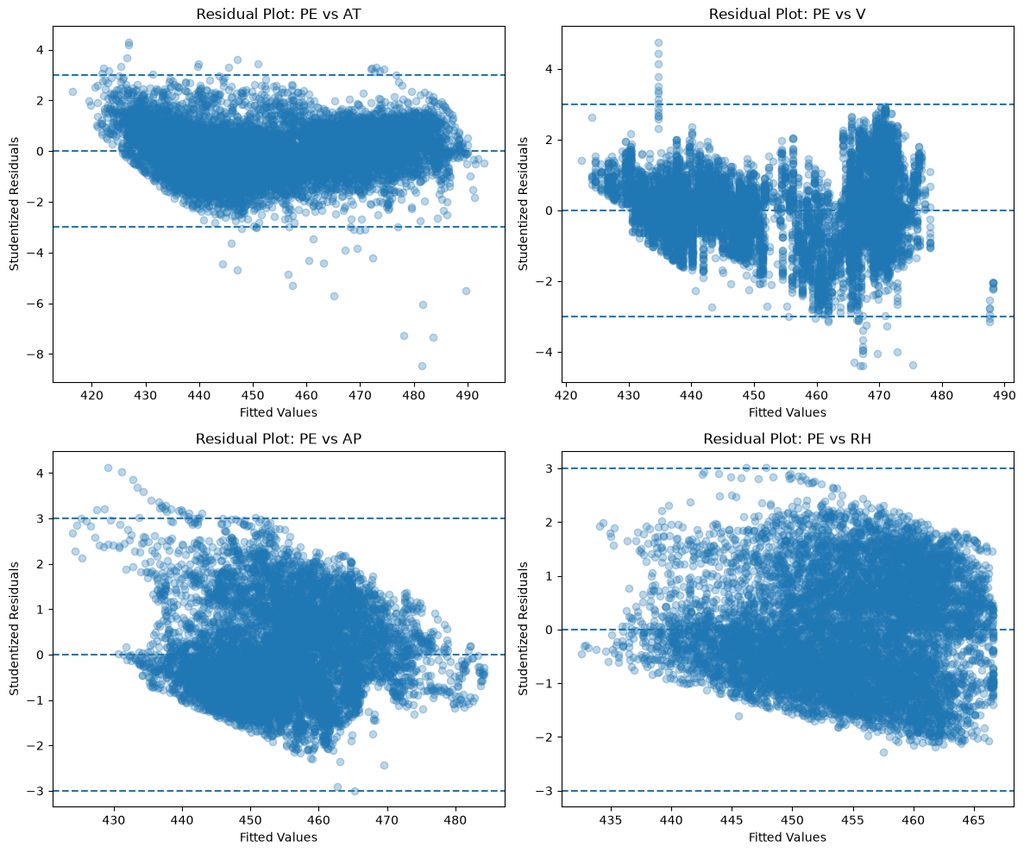

```python
# Studentized residual plots

fig, axes = plt.subplots(2, 2, figsize=(12, 10))

for predictor, ax in zip(predictors, axes.flatten()):
    model = simple_models[predictor]
    influence = model.get_influence()
    studentized_residuals = influence.resid_studentized_internal

    ax.scatter(model.fittedvalues, studentized_residuals, alpha=0.3)
    ax.axhline(3, linestyle='--')
    ax.axhline(-3, linestyle='--')
    ax.axhline(0, linestyle='--')

    ax.set_title(f'Residual Plot: PE vs {predictor}')
    ax.set_xlabel('Fitted Values')
    ax.set_ylabel('Studentized Residuals')

plt.tight_layout()
plt.show()
```

**Outliers:**

Using studentized residuals with a threshold of |3|, there are 42 potential outliers for AT, 33 for V, 29 for AP, and 2 for RH.

Although some observations have large studentized residuals, I would not remove them without evidence that they are measurement or data-entry errors. The residual plots also show some systematic patterns, especially for V, AP, and RH, suggesting that part of the issue may come from nonlinearity or model misspecification rather than true outliers.

### (d) Multiple Regression

```python
# Multiple linear regression using all predictors

multiple_model = smf.ols(
    'PE ~ AT + V + AP + RH',
    data=data
).fit()

multiple_model.summary()
```

OLS Regression Results

| Dep. Variable: | PE | R-squared: | 0.929 |
| --- | --- | --- | --- |
| Model: | OLS | Adj. R-squared: | 0.929 |
| Method: | Least Squares | F-statistic: | 3.114e+04 |
| Date: | Fri, 25 Sep 2026 | Prob (F-statistic): | 0.00 |
| Time: | 14:41:50 | Log-Likelihood: | -28088. |
| No. Observations: | 9568 | AIC: | 5.619e+04 |
| Df Residuals: | 9563 | BIC: | 5.622e+04 |
| Df Model: | 4 |  |  |
| Covariance Type: | nonrobust |  |  |

|  | coef | std err | t | P>\|t\| | [0.025 | 0.975] |
| --- | --- | --- | --- | --- | --- | --- |
| Intercept | 454.6093 | 9.749 | 46.634 | 0.000 | 435.500 | 473.718 |
| AT | -1.9775 | 0.015 | -129.342 | 0.000 | -2.007 | -1.948 |
| V | -0.2339 | 0.007 | -32.122 | 0.000 | -0.248 | -0.220 |
| AP | 0.0621 | 0.009 | 6.564 | 0.000 | 0.044 | 0.081 |
| RH | -0.1581 | 0.004 | -37.918 | 0.000 | -0.166 | -0.150 |

| Omnibus: | 892.002 | Durbin-Watson: | 2.033 |
| --- | --- | --- | --- |
| Prob(Omnibus): | 0.000 | Jarque-Bera (JB): | 4086.777 |
| Skew: | -0.352 | Prob(JB): | 0.00 |
| Kurtosis: | 6.123 | Cond. No. | 2.13e+05 |

Notes:  
[1] Standard Errors assume that the covariance matrix of the errors is correctly specified.  
[2] The condition number is large, 2.13e+05. This might indicate that there are  
strong multicollinearity or other numerical problems.

```python
# Coefficients and p-values of the multiple regression model

multiple_results = pd.DataFrame({
    'Coefficient': multiple_model.params,
    'Std. Error': multiple_model.bse,
    't-statistic': multiple_model.tvalues,
    'p-value': multiple_model.pvalues
})

multiple_results
```

|  | Coefficient | Std. Error | t-statistic | p-value |
| --- | --- | --- | --- | --- |
| Intercept | 454.609274 | 9.748512 | 46.633709 | 0.000000e+00 |
| AT | -1.977513 | 0.015289 | -129.342024 | 0.000000e+00 |
| V | -0.233916 | 0.007282 | -32.122109 | 4.375305e-215 |
| AP | 0.062083 | 0.009458 | 6.564086 | 5.507109e-11 |
| RH | -0.158054 | 0.004168 | -37.918473 | 3.104584e-293 |

**Results:**

The multiple linear regression model has an R-squared of 0.929, indicating that approximately 92.9% of the variation in PE is explained by AT, V, AP, and RH together.

All four predictors are statistically significant because their p-values are below 0.05. Therefore, we reject the null hypothesis H0: βj = 0 for AT, V, AP, and RH.

Holding the other predictors fixed:

- A one-unit increase in AT is associated with about a 1.9775-unit decrease in PE.
- A one-unit increase in V is associated with about a 0.2339-unit decrease in PE.
- A one-unit increase in AP is associated with about a 0.0621-unit increase in PE.
- A one-unit increase in RH is associated with about a 0.1581-unit decrease in PE.

### (e) 1c Compare to 1d

```python
# Compare simple and multiple regression coefficients

coefficient_comparison = pd.DataFrame({
    'Simple Regression': simple_results.set_index('Predictor')['Coefficient'],
    'Multiple Regression': multiple_model.params[predictors]
})

coefficient_comparison
```

|  | Simple Regression | Multiple Regression |
| --- | --- | --- |
| AT | -2.171320 | -1.977513 |
| V | -1.168135 | -0.233916 |
| AP | 1.489872 | 0.062083 |
| RH | 0.455650 | -0.158054 |

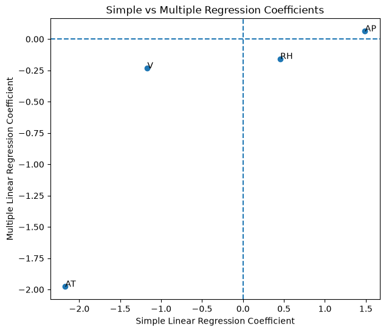

```python
# Plot simple vs multiple regression coefficients

plt.figure(figsize=(7, 6))

plt.scatter(
    coefficient_comparison['Simple Regression'],
    coefficient_comparison['Multiple Regression']
)

for predictor in predictors:
    plt.annotate(
        predictor,
        (
            coefficient_comparison.loc[predictor, 'Simple Regression'],
            coefficient_comparison.loc[predictor, 'Multiple Regression']
        )
    )

plt.axhline(0, linestyle='--')
plt.axvline(0, linestyle='--')

plt.xlabel('Simple Linear Regression Coefficient')
plt.ylabel('Multiple Linear Regression Coefficient')
plt.title('Simple vs Multiple Regression Coefficients')

plt.show()
```

**Comparison:**

The coefficients from the simple and multiple regression models are noticeably different.

AT changes only slightly, from -2.1713 in the simple regression to -1.9775 in the multiple regression.

The coefficient of V decreases substantially in magnitude, from -1.1681 to -0.2339. AP also decreases greatly, from 1.4899 to 0.0621.

The largest qualitative change occurs for RH. Its coefficient is positive in the simple regression (0.4557) but becomes negative in the multiple regression (-0.1581).

These differences occur because the simple regression considers each predictor separately, while the multiple regression estimates the association of each predictor with PE while holding the other predictors fixed. Since some predictors are related to each other, their estimated coefficients can change when they are included together in the model.

### (f) Nonlinear Association

```python
# Cubic polynomial regression for each predictor

polynomial_models = {}

for predictor in predictors:
    model = smf.ols(
        f'PE ~ {predictor} + I({predictor}**2) + I({predictor}**3)',
        data=data
    ).fit()

    polynomial_models[predictor] = model
```

```python
# P-values for quadratic and cubic terms

nonlinear_results = []

for predictor in predictors:
    model = polynomial_models[predictor]

    nonlinear_results.append({
        'Predictor': predictor,
        'Linear p-value': model.pvalues[predictor],
        'Quadratic p-value': model.pvalues[f'I({predictor} ** 2)'],
        'Cubic p-value': model.pvalues[f'I({predictor} ** 3)'],
        'R-squared': model.rsquared
    })

nonlinear_results = pd.DataFrame(nonlinear_results)
nonlinear_results
```

|  | Predictor | Linear p-value | Quadratic p-value | Cubic p-value | R-squared |
| --- | --- | --- | --- | --- | --- |
| 0 | AT | 7.898147e-07 | 8.833045e-73 | 3.652185e-110 | 0.911883 |
| 1 | V | 2.526589e-05 | 7.684969e-01 | 1.373489e-02 | 0.775022 |
| 2 | AP | 4.502735e-17 | 3.666705e-17 | 8.264146e-18 | 0.274863 |
| 3 | RH | 3.772510e-04 | 9.395430e-06 | 1.440279e-05 | 0.153743 |

**Results:**

There is evidence of nonlinear association between PE and all four predictors.

For AT, both the quadratic and cubic terms are statistically significant. For V, the quadratic term is not significant, but the cubic term is significant, which still provides evidence of a nonlinear relationship. For AP and RH, both the quadratic and cubic terms are statistically significant.

Therefore, AT, V, AP, and RH all show evidence of nonlinear association with PE.

### (g) Interactions of Predictors

```python
# Full linear regression model with all pairwise interactions

interaction_model = smf.ols(
    'PE ~ (AT + V + AP + RH) ** 2',
    data=data
).fit()

interaction_model.summary()
```

OLS Regression Results

| Dep. Variable: | PE | R-squared: | 0.936 |
| --- | --- | --- | --- |
| Model: | OLS | Adj. R-squared: | 0.936 |
| Method: | Least Squares | F-statistic: | 1.405e+04 |
| Date: | Fri, 25 Sep 2026 | Prob (F-statistic): | 0.00 |
| Time: | 14:55:32 | Log-Likelihood: | -27548. |
| No. Observations: | 9568 | AIC: | 5.512e+04 |
| Df Residuals: | 9557 | BIC: | 5.520e+04 |
| Df Model: | 10 |  |  |
| Covariance Type: | nonrobust |  |  |

|  | coef | std err | t | P>\|t\| | [0.025 | 0.975] |
| --- | --- | --- | --- | --- | --- | --- |
| Intercept | 685.7825 | 78.640 | 8.721 | 0.000 | 531.631 | 839.934 |
| AT | -4.3470 | 2.373 | -1.832 | 0.067 | -8.999 | 0.305 |
| V | -7.6749 | 1.351 | -5.682 | 0.000 | -10.323 | -5.027 |
| AP | -0.1524 | 0.077 | -1.983 | 0.047 | -0.303 | -0.002 |
| RH | 1.5709 | 0.773 | 2.031 | 0.042 | 0.055 | 3.087 |
| AT:V | 0.0210 | 0.001 | 23.338 | 0.000 | 0.019 | 0.023 |
| AT:AP | 0.0018 | 0.002 | 0.752 | 0.452 | -0.003 | 0.006 |
| AT:RH | -0.0052 | 0.001 | -6.444 | 0.000 | -0.007 | -0.004 |
| V:AP | 0.0068 | 0.001 | 5.135 | 0.000 | 0.004 | 0.009 |
| V:RH | 0.0008 | 0.000 | 1.716 | 0.086 | -0.000 | 0.002 |
| AP:RH | -0.0016 | 0.001 | -2.125 | 0.034 | -0.003 | -0.000 |

| Omnibus: | 1454.609 | Durbin-Watson: | 2.030 |
| --- | --- | --- | --- |
| Prob(Omnibus): | 0.000 | Jarque-Bera (JB): | 9170.848 |
| Skew: | -0.574 | Prob(JB): | 0.00 |
| Kurtosis: | 7.657 | Cond. No. | 1.70e+08 |

Notes:  
[1] Standard Errors assume that the covariance matrix of the errors is correctly specified.  
[2] The condition number is large, 1.7e+08. This might indicate that there are  
strong multicollinearity or other numerical problems.

```python
# P-values of pairwise interaction terms

interaction_terms = [
    'AT:V',
    'AT:AP',
    'AT:RH',
    'V:AP',
    'V:RH',
    'AP:RH'
]

interaction_results = pd.DataFrame({
    'Coefficient': interaction_model.params[interaction_terms],
    'p-value': interaction_model.pvalues[interaction_terms]
})

interaction_results
```

|  | Coefficient | p-value |
| --- | --- | --- |
| AT:V | 0.020971 | 3.333358e-117 |
| AT:AP | 0.001759 | 4.520509e-01 |
| AT:RH | -0.005230 | 1.216944e-10 |
| V:AP | 0.006812 | 2.877026e-07 |
| V:RH | 0.000839 | 8.619366e-02 |
| AP:RH | -0.001612 | 3.360557e-02 |

**Results:**

Four of the six pairwise interaction terms are statistically significant at the 0.05 level: AT:V, AT:RH, V:AP, and AP:RH.

The interaction terms AT:AP and V:RH are not statistically significant because their p-values are greater than 0.05.

Therefore, there is evidence that some predictors interact with each other in their association with PE.

### (h) Improvement

```python
# Split data into 70% training and 30% testing sets

train_data, test_data = train_test_split(
    data,
    test_size=0.30,
    random_state=1
)

print("Training set size:", train_data.shape)
print("Testing set size:", test_data.shape)
```

```
Training set size: (6697, 5)
Testing set size: (2871, 5)
```

```python
# Multiple linear regression with all predictors

linear_train_model = smf.ols(
    'PE ~ AT + V + AP + RH',
    data=train_data
).fit()

# Predictions
linear_train_pred = linear_train_model.predict(train_data)
linear_test_pred = linear_train_model.predict(test_data)

# MSE
linear_train_mse = mean_squared_error(
    train_data['PE'],
    linear_train_pred
)

linear_test_mse = mean_squared_error(
    test_data['PE'],
    linear_test_pred
)

print("Linear Regression Train MSE:", linear_train_mse)
print("Linear Regression Test MSE:", linear_test_mse)
```

```
Linear Regression Train MSE: 20.766119761450952
Linear Regression Test MSE: 20.77747810688431
```

```python
# Full model with quadratic terms and pairwise interactions

full_formula = (
    'PE ~ AT + V + AP + RH '
    '+ I(AT**2) + I(V**2) + I(AP**2) + I(RH**2) '
    '+ AT:V + AT:AP + AT:RH + V:AP + V:RH + AP:RH'
)

full_improved_model = smf.ols(
    full_formula,
    data=train_data
).fit()

full_improved_model.summary()
```

OLS Regression Results

| Dep. Variable: | PE | R-squared: | 0.938 |
| --- | --- | --- | --- |
| Model: | OLS | Adj. R-squared: | 0.938 |
| Method: | Least Squares | F-statistic: | 7181. |
| Date: | Fri, 25 Sep 2026 | Prob (F-statistic): | 0.00 |
| Time: | 14:59:01 | Log-Likelihood: | -19192. |
| No. Observations: | 6697 | AIC: | 3.841e+04 |
| Df Residuals: | 6682 | BIC: | 3.852e+04 |
| Df Model: | 14 |  |  |
| Covariance Type: | nonrobust |  |  |

|  | coef | std err | t | P>\|t\| | [0.025 | 0.975] |
| --- | --- | --- | --- | --- | --- | --- |
| Intercept | -8171.8080 | 1416.708 | -5.768 | 0.000 | -1.09e+04 | -5394.608 |
| AT | -3.8103 | 3.684 | -1.034 | 0.301 | -11.032 | 3.412 |
| V | -3.7163 | 1.786 | -2.081 | 0.037 | -7.217 | -0.216 |
| AP | 16.8844 | 2.745 | 6.151 | 0.000 | 11.504 | 22.265 |
| RH | 4.7922 | 1.060 | 4.521 | 0.000 | 2.714 | 6.870 |
| I(AT ** 2) | 0.0159 | 0.004 | 4.341 | 0.000 | 0.009 | 0.023 |
| I(V ** 2) | -0.0009 | 0.001 | -1.010 | 0.312 | -0.003 | 0.001 |
| I(AP ** 2) | -0.0082 | 0.001 | -6.165 | 0.000 | -0.011 | -0.006 |
| I(RH ** 2) | -0.0020 | 0.000 | -6.346 | 0.000 | -0.003 | -0.001 |
| AT:V | 0.0117 | 0.003 | 3.692 | 0.000 | 0.005 | 0.018 |
| AT:AP | 0.0012 | 0.004 | 0.344 | 0.731 | -0.006 | 0.008 |
| AT:RH | -0.0067 | 0.002 | -3.664 | 0.000 | -0.010 | -0.003 |
| V:AP | 0.0032 | 0.002 | 1.844 | 0.065 | -0.000 | 0.007 |
| V:RH | 0.0005 | 0.001 | 0.620 | 0.535 | -0.001 | 0.002 |
| AP:RH | -0.0045 | 0.001 | -4.352 | 0.000 | -0.006 | -0.002 |

| Omnibus: | 1461.187 | Durbin-Watson: | 2.028 |
| --- | --- | --- | --- |
| Prob(Omnibus): | 0.000 | Jarque-Bera (JB): | 12922.950 |
| Skew: | -0.793 | Prob(JB): | 0.00 |
| Kurtosis: | 9.618 | Cond. No. | 2.81e+10 |

Notes:  
[1] Standard Errors assume that the covariance matrix of the errors is correctly specified.  
[2] The condition number is large, 2.81e+10. This might indicate that there are  
strong multicollinearity or other numerical problems.

```python
# Reduced model after removing insignificant higher-order terms

reduced_formula = (
    'PE ~ AT + V + AP + RH '
    '+ I(AT**2) + I(AP**2) + I(RH**2) '
    '+ AT:V + AT:RH + AP:RH'
)

reduced_model = smf.ols(
    reduced_formula,
    data=train_data
).fit()

reduced_model.summary()
```

OLS Regression Results

| Dep. Variable: | PE | R-squared: | 0.938 |
| --- | --- | --- | --- |
| Model: | OLS | Adj. R-squared: | 0.937 |
| Method: | Least Squares | F-statistic: | 1.004e+04 |
| Date: | Fri, 25 Sep 2026 | Prob (F-statistic): | 0.00 |
| Time: | 15:01:04 | Log-Likelihood: | -19198. |
| No. Observations: | 6697 | AIC: | 3.842e+04 |
| Df Residuals: | 6686 | BIC: | 3.849e+04 |
| Df Model: | 10 |  |  |
| Covariance Type: | nonrobust |  |  |

|  | coef | std err | t | P>\|t\| | [0.025 | 0.975] |
| --- | --- | --- | --- | --- | --- | --- |
| Intercept | -1.052e+04 | 1079.936 | -9.738 | 0.000 | -1.26e+04 | -8399.884 |
| AT | -2.3804 | 0.101 | -23.552 | 0.000 | -2.579 | -2.182 |
| V | -0.4548 | 0.031 | -14.496 | 0.000 | -0.516 | -0.393 |
| AP | 21.2291 | 2.134 | 9.950 | 0.000 | 17.046 | 25.412 |
| RH | 6.0882 | 0.763 | 7.976 | 0.000 | 4.592 | 7.585 |
| I(AT ** 2) | 0.0174 | 0.002 | 7.655 | 0.000 | 0.013 | 0.022 |
| I(AP ** 2) | -0.0102 | 0.001 | -9.687 | 0.000 | -0.012 | -0.008 |
| I(RH ** 2) | -0.0021 | 0.000 | -7.575 | 0.000 | -0.003 | -0.002 |
| AT:V | 0.0076 | 0.001 | 5.302 | 0.000 | 0.005 | 0.010 |
| AT:RH | -0.0071 | 0.001 | -8.079 | 0.000 | -0.009 | -0.005 |
| AP:RH | -0.0057 | 0.001 | -7.722 | 0.000 | -0.007 | -0.004 |

| Omnibus: | 1462.479 | Durbin-Watson: | 2.027 |
| --- | --- | --- | --- |
| Prob(Omnibus): | 0.000 | Jarque-Bera (JB): | 12609.274 |
| Skew: | -0.802 | Prob(JB): | 0.00 |
| Kurtosis: | 9.528 | Cond. No. | 2.14e+10 |

Notes:  
[1] Standard Errors assume that the covariance matrix of the errors is correctly specified.  
[2] The condition number is large, 2.14e+10. This might indicate that there are  
strong multicollinearity or other numerical problems.

```python
# Predictions from the reduced improved model

reduced_train_pred = reduced_model.predict(train_data)
reduced_test_pred = reduced_model.predict(test_data)

# Train and test MSE
reduced_train_mse = mean_squared_error(
    train_data['PE'],
    reduced_train_pred
)

reduced_test_mse = mean_squared_error(
    test_data['PE'],
    reduced_test_pred
)

print("Improved Model Train MSE:", reduced_train_mse)
print("Improved Model Test MSE:", reduced_test_mse)
```

```
Improved Model Train MSE: 18.093235651112646
Improved Model Test MSE: 18.2635881122737
```

```python
# Compare the two models

mse_comparison = pd.DataFrame({
    'Model': ['Linear Regression', 'Improved Regression'],
    'Train MSE': [linear_train_mse, reduced_train_mse],
    'Test MSE': [linear_test_mse, reduced_test_mse]
})

mse_comparison
```

|  | Model | Train MSE | Test MSE |
| --- | --- | --- | --- |
| 0 | Linear Regression | 20.766120 | 20.777478 |
| 1 | Improved Regression | 18.093236 | 18.263588 |

**Results:**

The ordinary multiple linear regression model has a training MSE of 20.7661 and a test MSE of 20.7775.

After including significant quadratic and interaction terms, the improved regression model has a lower training MSE of 18.0932 and a lower test MSE of 18.2636.

Therefore, adding nonlinear and interaction terms improves the predictive performance of the regression model.

### (i) KNN

```python
# Prepare training and testing data for KNN

X_train = train_data[['AT', 'V', 'AP', 'RH']]
y_train = train_data['PE']

X_test = test_data[['AT', 'V', 'AP', 'RH']]
y_test = test_data['PE']
```

```python
# KNN regression using raw features

k_values = range(1, 101)

raw_train_mse = []
raw_test_mse = []

for k in k_values:
    knn = KNeighborsRegressor(n_neighbors=k)
    knn.fit(X_train, y_train)

    train_pred = knn.predict(X_train)
    test_pred = knn.predict(X_test)

    raw_train_mse.append(
        mean_squared_error(y_train, train_pred)
    )

    raw_test_mse.append(
        mean_squared_error(y_test, test_pred)
    )
```

```python
# Best k for raw features

best_raw_index = np.argmin(raw_test_mse)
best_raw_k = list(k_values)[best_raw_index]
best_raw_test_mse = raw_test_mse[best_raw_index]

print("Best k for raw features:", best_raw_k)
print("Best test MSE for raw features:", best_raw_test_mse)
```

```
Best k for raw features: 5
Best test MSE for raw features: 15.704821203761764
```

```python
# Normalize the predictor variables

scaler = StandardScaler()

X_train_scaled = scaler.fit_transform(X_train)
X_test_scaled = scaler.transform(X_test)
```

```python
# KNN regression using normalized features

normalized_train_mse = []
normalized_test_mse = []

for k in k_values:
    knn = KNeighborsRegressor(n_neighbors=k)
    knn.fit(X_train_scaled, y_train)

    train_pred = knn.predict(X_train_scaled)
    test_pred = knn.predict(X_test_scaled)

    normalized_train_mse.append(
        mean_squared_error(y_train, train_pred)
    )

    normalized_test_mse.append(
        mean_squared_error(y_test, test_pred)
    )
```

```python
# Best k for normalized features

best_normalized_index = np.argmin(normalized_test_mse)
best_normalized_k = list(k_values)[best_normalized_index]
best_normalized_test_mse = normalized_test_mse[best_normalized_index]

print("Best k for normalized features:", best_normalized_k)
print("Best test MSE for normalized features:", best_normalized_test_mse)
```

```
Best k for normalized features: 4
Best test MSE for normalized features: 14.070606067136888
```

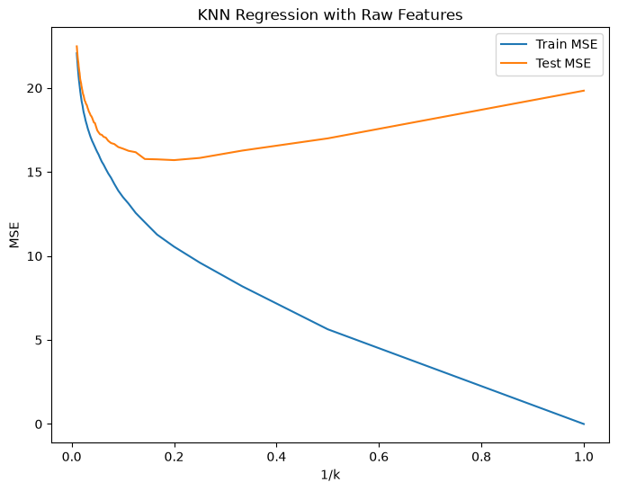

```python
# Train and test MSE for raw features versus 1/k

inverse_k = 1 / np.array(list(k_values))

plt.figure(figsize=(8, 6))

plt.plot(inverse_k, raw_train_mse, label='Train MSE')
plt.plot(inverse_k, raw_test_mse, label='Test MSE')

plt.xlabel('1/k')
plt.ylabel('MSE')
plt.title('KNN Regression with Raw Features')
plt.legend()

plt.show()
```

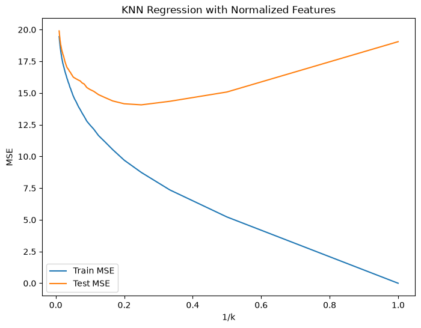

```python
# Train and test MSE for normalized features versus 1/k

plt.figure(figsize=(8, 6))

plt.plot(inverse_k, normalized_train_mse, label='Train MSE')
plt.plot(inverse_k, normalized_test_mse, label='Test MSE')

plt.xlabel('1/k')
plt.ylabel('MSE')
plt.title('KNN Regression with Normalized Features')
plt.legend()

plt.show()
```

**Results:**

For KNN regression using the raw features, the best value of k is 5, with a test MSE of approximately 15.7048.

For KNN regression using normalized features, the best value of k is 4, with a lower test MSE of approximately 14.0706.

Therefore, normalization improves the performance of KNN regression on this dataset. This is reasonable because KNN is based on distances, and the predictor variables are measured on different scales.

The plots also show that very small values of k can lead to overfitting, while very large values of k increase the test error.

### (j ) Compare KNN and Linear

```python
# Compare the best regression model with the best KNN model

final_comparison = pd.DataFrame({
    'Model': [
        'Improved Regression',
        'KNN with Normalized Features'
    ],
    'Best k': [
        np.nan,
        best_normalized_k
    ],
    'Test MSE': [
        reduced_test_mse,
        best_normalized_test_mse
    ]
})

final_comparison
```

|  | Model | Best k | Test MSE |
| --- | --- | --- | --- |
| 0 | Improved Regression | NaN | 18.263588 |
| 1 | KNN with Normalized Features | 4.0 | 14.070606 |

**Comparison:**

The improved regression model has a test MSE of approximately 18.2636, while the best KNN model using normalized features with k = 4 has a lower test MSE of approximately 14.0706.

Therefore, KNN regression provides better predictive performance on the test set for this dataset.

The improved regression model captures nonlinearities and interactions explicitly through polynomial and interaction terms, while KNN can capture more flexible local relationships without assuming a particular functional form. The lower test MSE of KNN suggests that these local nonlinear patterns are useful for predicting PE.

Overall, among the models tested, the normalized KNN model with k = 4 gives the lowest test error.

## 2. ISLR: 2.4.1

For each of parts (a) through (d), indicate whether we would generally expect the performance of a flexible statistical learning method to be better or worse than an inflexible method. Justify your answer.

### (a) The sample size n is extremely large, and the number of predictors p is small.

A flexible statistical learning method would generally perform **better**.

Since the sample size is extremely large and the number of predictors is small, there is enough data to estimate a flexible model reliably. The large sample size reduces the risk of overfitting, while the flexible method can capture more complex relationships in the data.

### (b) The number of predictors p is extremely large, and the number of observations n is small.

A flexible method would generally perform **worse**.

When the number of predictors is very large but the number of observations is small, a flexible method is more likely to overfit the training data. An inflexible method would have lower variance and may generalize better to new observations.

### (c) The relationship between the predictors and response is highly non-linear.

A flexible method would generally perform **better**.

If the relationship between the predictors and the response is highly nonlinear, a flexible method can adapt to the nonlinear pattern. An inflexible method may be too restrictive and have high bias.

### (d) The variance of the error terms, i.e. $σ^2$ = Var(ε), is extremely high.

A flexible method would generally perform **worse**.

When the variance of the error terms is extremely high, much of the variation in the response is due to noise. A flexible method may fit this noise rather than the true underlying relationship, which can lead to overfitting and high variance. An inflexible method is generally more stable in this situation.

## 3. ISLR: 2.4.7

### (a) Compute the Euclidean distance between each observation and the test point, X1 = X2 = X3 = 0.

The test point is:

$$(0,0,0)$$

Using Euclidean distance,

$$ d = \sqrt{(X_1-0)^2 + (X_2-0)^2 + (X_3-0)^2} $$

The distances are:

| Observation | Distance |
| --- | --- |
| 1 | $\sqrt{0^2+3^2+0^2}=3$ |
| 2 | $\sqrt{2^2+0^2+0^2}=2$ |
| 3 | $\sqrt{0^2+1^2+3^2}=\sqrt{10}$ |
| 4 | $\sqrt{0^2+1^2+2^2}=\sqrt{5}$ |
| 5 | $\sqrt{(-1)^2+0^2+1^2}=\sqrt{2}$ |
| 6 | $\sqrt{1^2+1^2+1^2}=\sqrt{3}$ |

Therefore, ordered from closest to farthest:

$$ 5,\ 6,\ 2,\ 4,\ 1,\ 3 $$

### (b) What is our prediction with K = 1? Why?

For $K=1$, the nearest observation to the test point $(0,0,0)$ is Observation 5.

Observation 5 has response **Green**.

Therefore, the predicted class is:

$$ \boxed{\text{Green}} $$

### (c) What is our prediction with K = 3? Why?

For $K=3$, the three nearest observations to the test point $(0,0,0)$ are:

- Observation 5: **Green**
- Observation 6: **Red**
- Observation 2: **Red**

Since two of the three nearest neighbors are Red, the majority vote is Red.

Therefore, the predicted class is:

$$ \boxed{\text{Red}} $$

### (d) If the Bayes decision boundary in this problem is highly non-linear, then would we expect the best value for K to be large or small? Why?

We would expect the best value of $K$ to be relatively **small**.

A small value of $K$ produces a more flexible decision boundary, which is better able to capture a highly nonlinear Bayes decision boundary.

In contrast, a large value of $K$ produces a smoother and less flexible decision boundary, which may fail to capture the nonlinear pattern.